# Лабораторная работа №1

Методы кодирования и модуляция сигналов

Устинова В. В.

Российский университет дружбы народов, Москва, Россия

12 сентября 2026

# Информация

## Докладчик

- Устинова Виктория Вадимовна
- студент НПИбд-01-24
- Российский университет дружбы народов

## Цель работы

Изучение методов кодирования и модуляции сигналов с помощью высокоуровнего языка программирования Octave. Определение спектра и параметров сигнала. Демонстрация принципов модуляции сигнала на примере аналоговой амплитудной модуляции. Исследование свойства самосинхронизации сигнала

## Задание

Построить графики функций в Octave с использованием функции plot и экспортировать их в файлы .eps и .png. Разработать код m-файла для построения графиков меандра с различным количеством гармоник. Найти спектры синусоидальных сигналов и их суммы с помощью быстрого преобразования Фурье. Продемонстрировать принципы амплитудной модуляции. Получить кодированные сигналы для нескольких кодов, проверить свойства самосинхронизируемости и получить спектры.

# Выполнение лабораторной работы

## График функции y1

Построить график функции 𝑦 = sin 𝑥 + 1/3 sin 3𝑥 + 1/5 sin 5𝑥 на интервале −10; 10, используя Octave и функцию plot

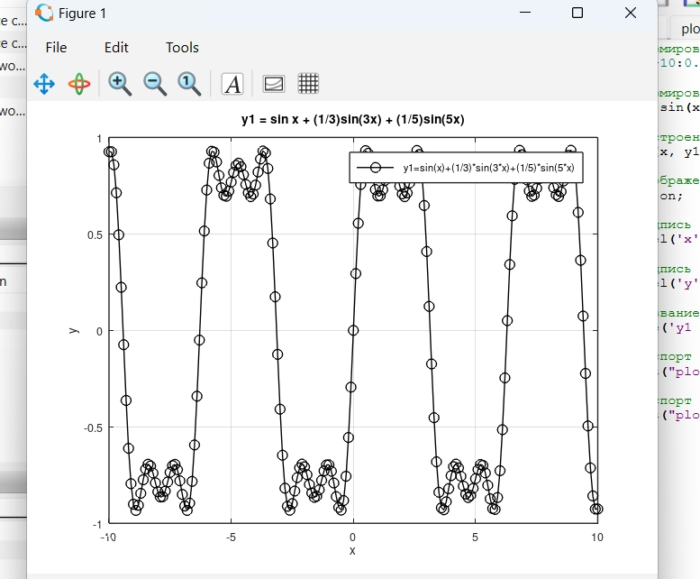

Построен график функции y1 с маркерами и сеткой

## Добавление графика функции y2

Добавить график функции y = cos x + (1/3)cos 3x + (1/5)cos 5x на интервале -10; 10и экспортировать оба графика в файлы .eps и .png

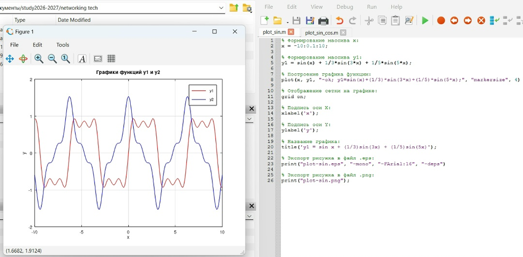

На одном графике построены функции y1 и y2 разными линиями, показан код сценария.

## Построение графиков меандра.

Разработать код m-файла, результатом выполнения которого являются графики меандра, реализованные с различным количеством гармоник.

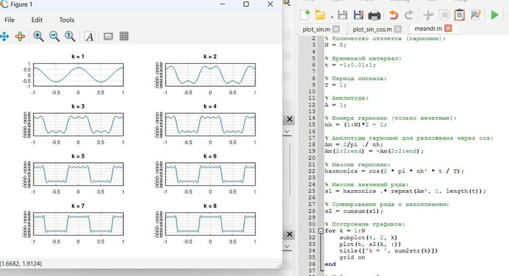

Построены 8 графиков меандра для k = 1…8 с разным числом гармоник.

## Спектры синусоидальных сигналов.

Найти спектры синусоидальных сигналов с помощью быстрого преобразования Фурье. Учесть реализацию преобразования Фурье и скорректировать график спектра, отбросив дублирующие отрицательные частоты

[figure not shown]

Показаны два сигнала разной частоты, их спектры и исправленный график спектра.

## Спектр суммарного сигнала.

Найти спектр суммы рассмотренных сигналов. Спектр суммы сигналов должен быть равен сумме спектров сигналов, что вытекает из свойств преобразования Фурье.

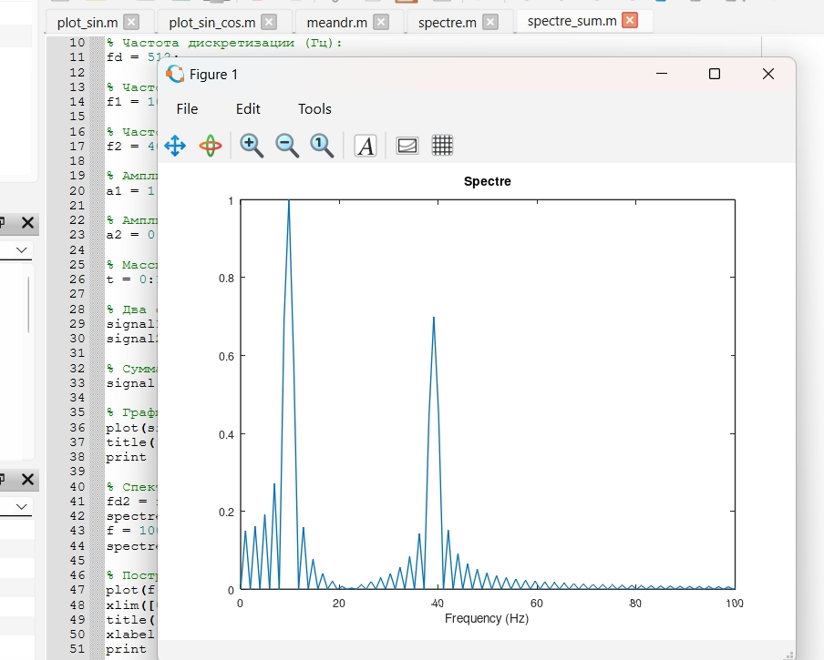

Построен график спектра суммарного сигнала с двумя пиками на частотах 10 и 40 Гц.

## Амплитудная модуляция.

Продемонстрировать принципы модуляции сигнала на примере аналоговой амплитудной модуляции. Спектр произведения представляет собой свёртку спектров.

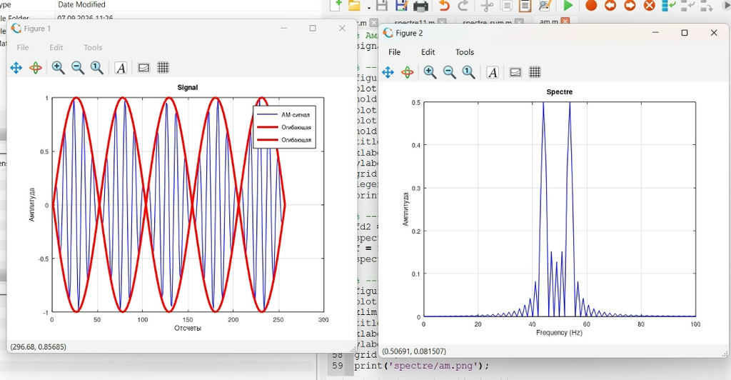

Показан АМ-сигнал с огибающей и его спектр с двумя боковыми составляющими

## Кодированные сигналы.

По заданным битовым последовательностям получить кодированные сигналы для нескольких кодов: униполярного, AMI, NRZ, RZ, манчестерского и дифференциального манчестерского

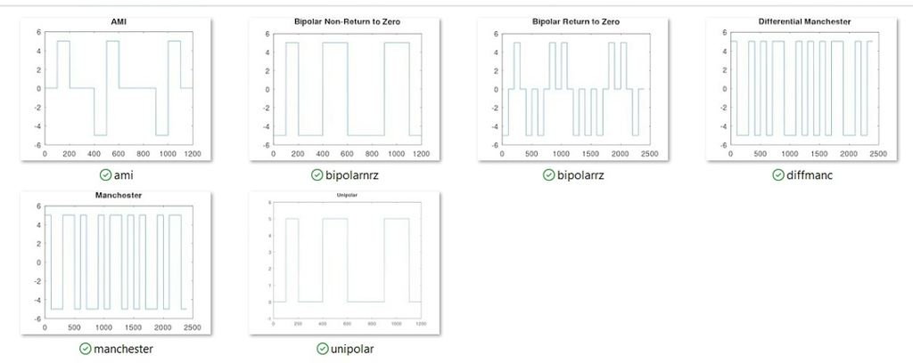

Построены графики шести кодированных сигналов для последовательности data

## Спектры кодированных сигналов.

Получить спектры кодированных сигналов с помощью функции calcspectre для всех рассмотренных кодов

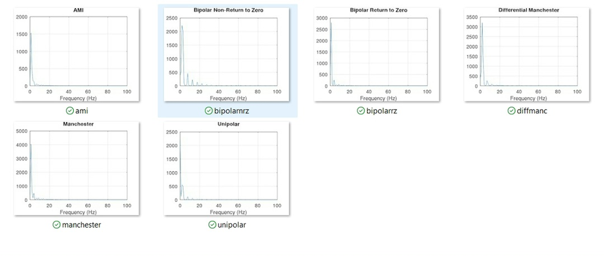

Построены графики спектров шести кодированных сигналов.

## Исследование самосинхронизации кодов.

Проверить свойства самосинхронизируемости кодов, получив кодированные сигналы для последовательности data_sync.

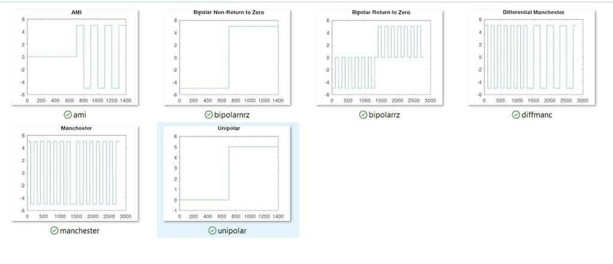